# Praca domowa 2

Karolina Jagielak

## Dane

Dane wykorzystane w Pracy domowej 2 dotyczą wyników egzaminów z 3 umiejętności: czytania, pisania i operacji matematycznych. Dodatkowo dostępne są podstawowe informacje o studentach i ich rodzicach. Opis wszystkich kolumn znajduje się również w pliku `README.md`.

| Zmienna | Opis |
| --- | --- |
| **gender** | płeć |
| **race.ethnicity** | pochodzenie etniczne |
| **parental.level.of.education** | wykształcenie rodziców |
| **lunch** | jaki obiad jedli uczniowie w dniu egzaminu |
| **test.preparation.course** | czy uczeń odbył kurs przygotowujący |
| **math.score** | wynik egzaminu z matematyki |
| **reading.score** | wynik egzaminu z czytania |
| **writing.score** | wynik egzaminu z pisania |

## Zadanie 1

Jak wyglądają rozkłady wyników uczniów z trzech przedmiotów (matematyka, czytanie, pisanie)?

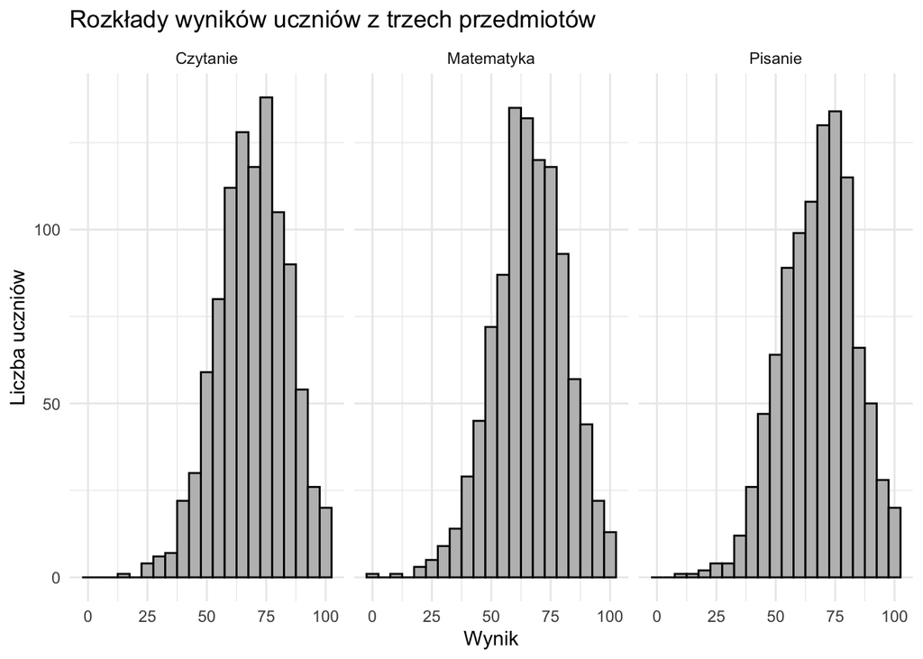

```r
# Tu umieść kod do wygenerowania odpowiedzi do zadania.
df_long <- df%>%
  pivot_longer(cols = c(math.score, reading.score, writing.score), names_to = "Przedmioty",values_to = "Wynik")%>%
  mutate(Przedmioty = recode(Przedmioty,"reading.score" = "Czytanie","writing.score" = "Pisanie", "math.score"= "Matematyka"))

ggplot(df_long, aes(x = Wynik)) +
  geom_histogram(binwidth = 5 , fill = "grey", color = "black") +
  facet_wrap(~Przedmioty)+
  theme_minimal() +
  labs(title = "Rozkłady wyników uczniów z trzech przedmiotów",
       x = "Wynik", y = "Liczba uczniów")
```

**Komentarz:**

Na przedstawionym wykresie rozkładów wyników uczniów z trzech przedmiotów, Czytania, Matematyki i Pisania, można zauważyć wyraźne różnice w osiąganych rezultatach.

Uczniowie uzyskali lepsze wyniki z Czytania i Pisania niż z Matematyki. Dla tych dwóch przedmiotów wartości najczęściej występujące wynoszą około 75 punktów, podczas gdy dla Matematyki maksimum rozkładu jest przesunięte w lewo i wynosi około 60 punktów. Oznacza to, że przeciętnie uczniowie osiągają niższe rezultaty z Matematyki.

Rozkłady wyników dla Czytania i Pisania są do siebie bardzo zbliżone pod względem kształtu i położenia, co sugeruje, że kompetencje językowe uczniów w obu obszarach są na podobnym poziomie. W przypadku Matematyki widoczny jest niższy poziom centralny wyników, przy jednocześnie podobnym stopniu rozproszenia, jak w pozostałych przedmiotach.

Wszystkie trzy histogramy mają kształt zbliżony do rozkładu normalnego, co świadczy o równomiernym rozkładzie wyników wokół wartości średnich oraz o braku znacznych wartości odstających.

Podsumowując, analiza wskazuje, że:

• uczniowie lepiej radzą sobie z Czytaniem i Pisaniem,

• słabiej wypadają w Matematyce,

• rozkłady wyników są symetryczne i zbliżone do normalnych,

• wyniki z przedmiotów czytania i pisania są do siebie bardzo podobne.

## Zadanie 2

Czy istnieje zauważalna różnica w wynikach między uczniami i uczennicami?

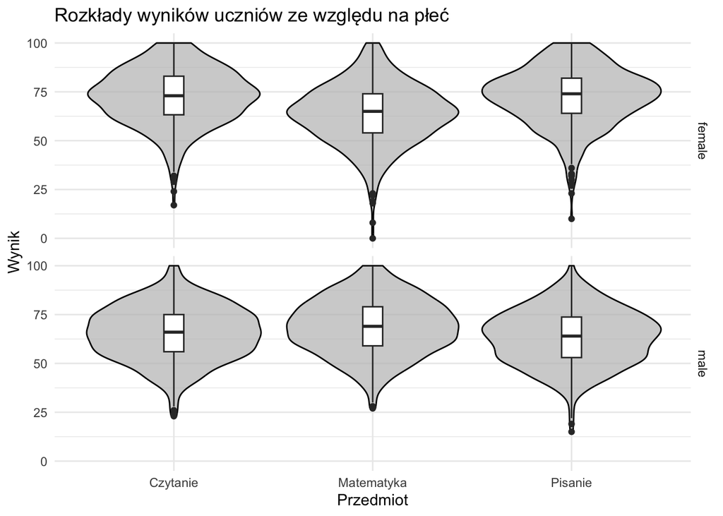

```r
# Tu umieść kod do wygenerowania odpowiedzi do zadania.
ggplot(df_long, aes(x = Przedmioty, y = Wynik )) +
  geom_violin(trim = TRUE, color= "black", fill = "grey" ,alpha = 0.7) +
  geom_boxplot(width = 0.1)+
  facet_grid(gender~.) +
  theme_minimal() +
  labs(title = "Rozkłady wyników uczniów ze względu na płeć",
       x = "Przedmiot", y = "Wynik")
```

**Komentarz:**

Na wykresie można zauważyć, że dziewczęta uzyskują wyższe wyniki z Czytania i Pisania niż chłopcy. Świadczą o tym wyższe mediany oraz fakt, że rozkłady wyników dziewcząt są bardziej skoncentrowane w obszarze wyższych wartości. Oznacza to, że uczennice częściej osiągają dobre i bardzo dobre wyniki w tych obszarach, co może wskazywać na lepiej rozwinięte kompetencje językowe.

W przypadku Matematyki sytuacja wygląda odwrotnie, mediana wyników jest nieco wyższa u chłopców, co sugeruje, że przeciętnie osiągają oni lepsze rezultaty z tego przedmiotu. Dodatkowo u dziewcząt widoczne są wartości skrajne (outliery), obejmujące bardzo niskie wyniki (np. bliskie 0 lub 8 punktów), które nie występują wśród chłopców.

Jeśli chodzi o kształt rozkładów, można zauważyć, że:

• u dziewcząt są one bardziej strome i skupione wokół mediany, co oznacza większą spójność wyników, większość uczennic osiąga zbliżone rezultaty;

• u chłopców rozkłady są bardziej płynne i gładkie, co wskazuje na większe zróżnicowanie wyników, w tej grupie obserwuje się zarówno wysokie, jak i niższe wyniki w podobnych proporcjach.

Podsumowując, dziewczęta osiągają lepsze i bardziej jednolite wyniki w przedmiotach humanistycznych, natomiast chłopcy uzyskują nieco lepsze rezultaty z Matematyki, przy jednocześnie większej zmienności wyników ogółem.

## Zadanie 3

Czy uczniowie, którzy ukończyli kurs przygotowawczy, osiągają lepsze wyniki niż pozostali?

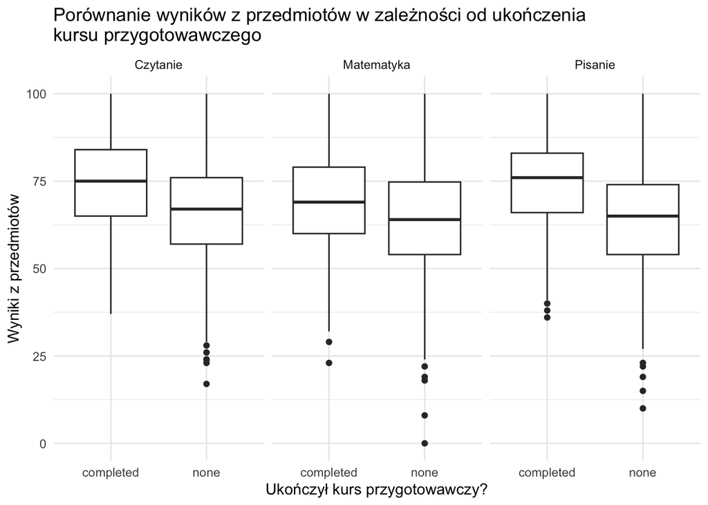

```r
# Tu umieść kod do wygenerowania odpowiedzi do zadania.
ggplot(df_long, aes(x = test.preparation.course, y = Wynik) )+
  geom_boxplot() +
  facet_grid(~Przedmioty) +
  labs(
    title = "Porównanie wyników z przedmiotów w zależności od ukończenia \nkursu przygotowawczego",
    x = "Ukończył kurs przygotowawczy?",
    y = "Wyniki z przedmiotów"
  ) + theme_minimal()+theme(legend.position = "none")
```

**Komentarz:**

Na wykresie można zauważyć, że we wszystkich analizowanych przedmiotach mediany wyników są wyższe wśród uczniów, którzy uczestniczyli w kursach przygotowawczych, w porównaniu z osobami, które w nich nie brały udziału. Wskazuje to, że udział w kursach przygotowawczych wiąże się z lepszymi rezultatami nauczania i może mieć pozytywny wpływ na osiągnięcia uczniów.

Jednocześnie można zauważyć, że różnica między medianami jest najmniejsza w przypadku Matematyki. Sugeruje to, że kursy przygotowawcze miały mniejsze znaczenie w poprawie wyników z tego przedmiotu niż w przypadku Czytania i Pisania, gdzie różnice pomiędzy grupami są bardziej wyraźne.

Rozkłady wyników dla obu grup są zbliżone pod względem kształtu i rozproszenia, co oznacza, że kursy wpłynęły głównie na przesunięcie wartości centralnych, a nie na zwiększenie lub zmniejszenie zróżnicowania wyników. Można więc wnioskować, że udział w kursach pomagał uczniom osiągać lepsze wyniki, ale nie wpływał istotnie na ogólną zmienność rezultatów w grupie.

Podsumowując, kursy przygotowawcze sprzyjały poprawie wyników, szczególnie w przedmiotach humanistycznych (Czytanie, Pisanie), natomiast efekt ten był słabszy w przypadku Matematyki, co może wynikać z innego charakteru nabywanych kompetencji lub różnic w skuteczności metodyki nauczania.

## Zadanie 4

Jaki jest związek między poziomem wykształcenia rodziców a średnimi wynikami uczniów?

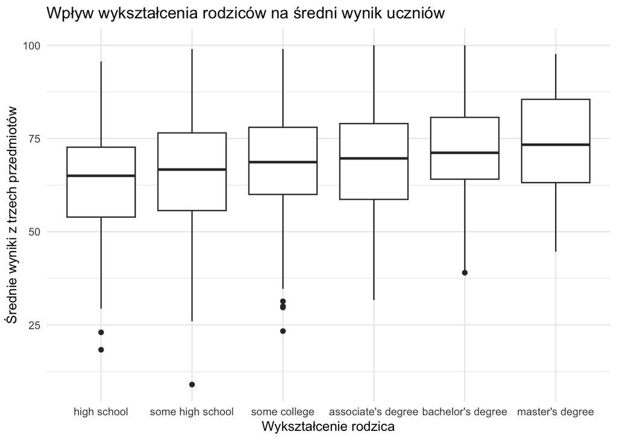

```r
# Tu umieść kod do wygenerowania odpowiedzi do zadania.
library(forcats)

df <- df%>%
  mutate(srednia_ocen = (math.score + reading.score + writing.score)/3 )
ggplot(df, aes(x = fct_reorder(parental.level.of.education, srednia_ocen, .fun = median), y = srednia_ocen )) +
  geom_boxplot()+
  theme_minimal()+
  labs(title = "Wpływ wykształcenia rodziców na średni wynik uczniów",x = "Wykształcenie rodzica",
        y = "Średnie wyniki z trzech przedmiotów")
```

## Zadanie 5

Czy płeć i wykształcenie rodzica wpływa na wynik z matematyki?

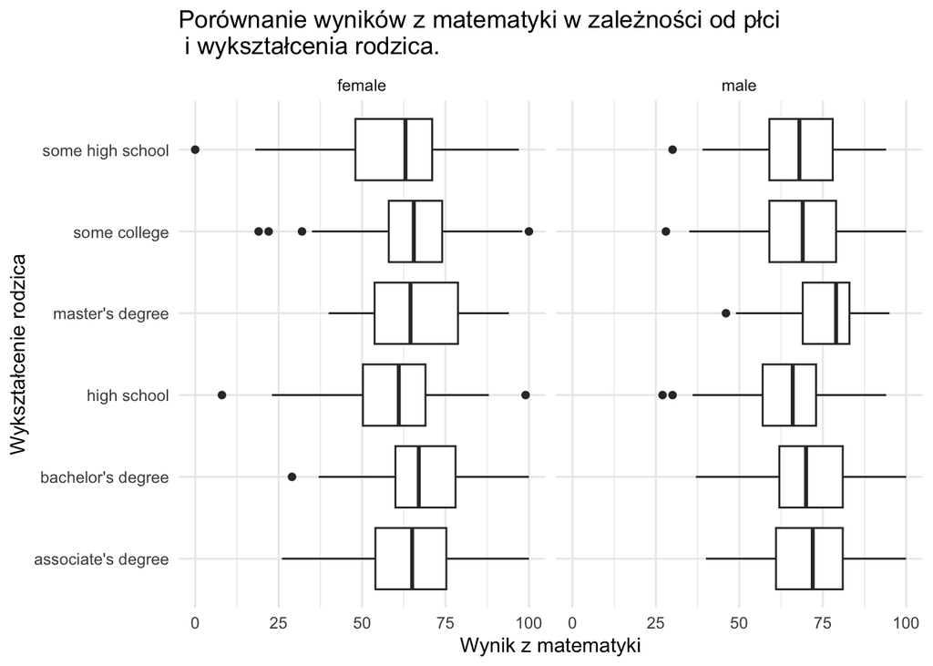

```r
# Tu umieść kod do wygenerowania odpowiedzi do zadania.
ggplot(df, aes(x = parental.level.of.education, y = math.score)) +
  geom_boxplot()+
  facet_wrap(~gender) +
  coord_flip() +
  theme_minimal() +
  labs(
    title = "Porównanie wyników z matematyki w zależności od płci\n i wykształcenia rodzica.",
    y = "Wynik z matematyki",
    x = "Wykształcenie rodzica"
  )
```

**Komentarz:**

W przypadku mężczyzn można zauważyć, że poziom wykształcenia rodziców ma wpływ na wyniki z matematyki. Porównując mediany ocen, widać, że najwyższe wartości występują, gdy rodzic posiada tytuł master’s degree, a najniższe, gdy ukończył jedynie high school.

W przypadku kobiet nie obserwuje się wyraźnej zależności między poziomem wykształcenia rodziców a wynikami z matematyki. Mediany ocen są bardzo zbliżone, niezależnie od poziomu wykształcenia rodzica, natomiast rozrzut ocen jest znacznie większy niż u mężczyzn. Można zatem przypuszczać, że na wyniki kobiet wpływają inne czynniki niż wykształcenie rodziców.

## Zadanie 6

Czy istnieje zależność między wynikami z matematyki a wynikami z czytania lub pisania?

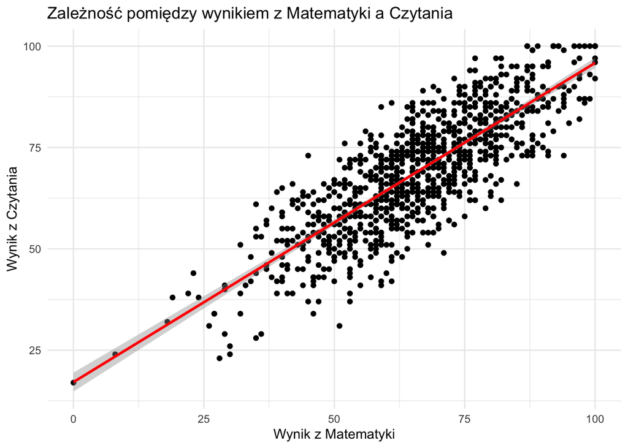

```r
# Tu umieść kod do wygenerowania odpowiedzi do zadania.

# Zależność między wynikiem z Matematyki a Czytaniem
ggplot(df, aes (x = math.score, y = reading.score))+
  geom_point() +
  geom_smooth(method = "lm", se = TRUE, color = "red")+
  theme_minimal() +
  labs(title = "Zależność pomiędzy wynikiem z Matematyki a Czytania",
       x = "Wynik z Matematyki",
       y = "Wynik z Czytania")
```

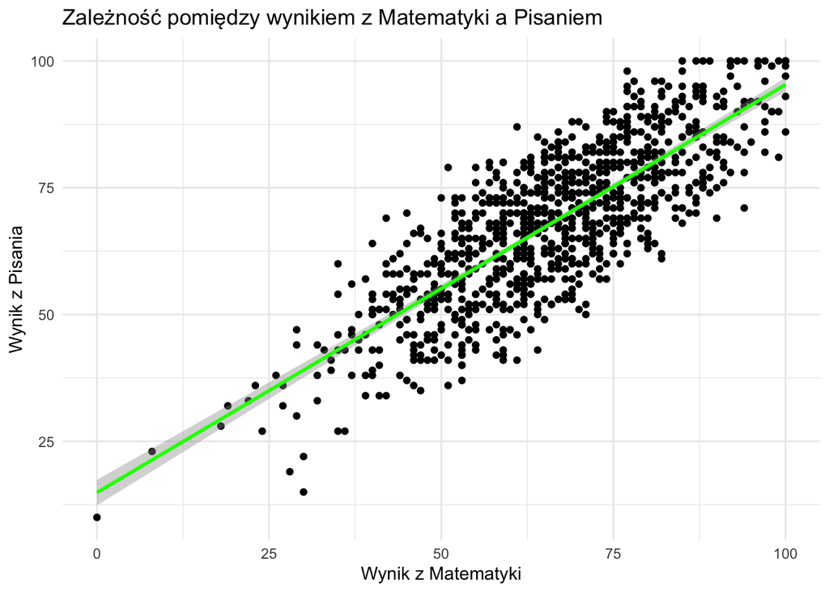

```r
# Zależność między wynikiem z Matematyki a Pisania
ggplot(df, aes(x = math.score, y = writing.score)) +
  geom_point()+
  geom_smooth(method = "lm", se= TRUE, color = "green")+
  theme_minimal() +
  labs(title = "Zależność pomiędzy wynikiem z Matematyki a Pisaniem",
       x = "Wynik z Matematyki",
       y = "Wynik z Pisania")
```

**Komentarz:**

Tak, istnieje zależność między wynikami z matematyki a wynikiem z czytania bądź pisania. Z wykresów stworzonych za pomocą kodu powyżej można zauważyć, że im wyższy wynik z matematyki, tym wyższe są również oceny z czytania bądż pisania. To znaczy że uczniowie osiągający dobre z wyniki z matematyki mają tendecje do osiągania również wysokich ocen z pisania i czytania.